# The Anatomy of a Hit - What Drives Song Popularity?

Quynh Vo

2025-08-28

This is one of the projects from the Regression Analysis course in my third year undergrad. The analysis is conducted on the data set I was given in the course, thus I have no idea where the data comes from. I uploaded the data file (`spotify.csv`) in the same folder containing this Rmarkdown file.

Let’s start with having a look at our data set.

```r
#import data
df <- read.csv("spotify.csv")
head(df)
```

```
##   popularity duration_ms danceability energy acousticness instrumentalness
## 1         73      230666        0.676 0.4610       0.0322         1.01e-06
## 2         55      149610        0.420 0.1660       0.9240         5.56e-06
## 3         57      210826        0.438 0.3590       0.2100         0.00e+00
## 4         71      201933        0.266 0.0596       0.9050         7.07e-05
## 5         82      198853        0.618 0.4430       0.4690         0.00e+00
## 6         58      214240        0.688 0.4810       0.2890         0.00e+00
##   liveness   tempo
## 1   0.3580  87.917
## 2   0.1010  77.489
## 3   0.1170  76.332
## 4   0.1320 181.740
## 5   0.0829 119.949
## 6   0.1890  98.017
```

```r
#look at the structure of df
str(df)
```

```
## 'data.frame':    114000 obs. of  8 variables:
##  $ popularity      : int  73 55 57 71 82 58 74 80 74 56 ...
##  $ duration_ms     : int  230666 149610 210826 201933 198853 214240 229400 242946 189613 205594 ...
##  $ danceability    : num  0.676 0.42 0.438 0.266 0.618 0.688 0.407 0.703 0.625 0.442 ...
##  $ energy          : num  0.461 0.166 0.359 0.0596 0.443 0.481 0.147 0.444 0.414 0.632 ...
##  $ acousticness    : num  0.0322 0.924 0.21 0.905 0.469 0.289 0.857 0.559 0.294 0.426 ...
##  $ instrumentalness: num  1.01e-06 5.56e-06 0.00 7.07e-05 0.00 0.00 2.89e-06 0.00 0.00 4.19e-03 ...
##  $ liveness        : num  0.358 0.101 0.117 0.132 0.0829 0.189 0.0913 0.0973 0.151 0.0735 ...
##  $ tempo           : num  87.9 77.5 76.3 181.7 119.9 ...
```

```r
#count missing values in each column
colSums(is.na(df))
```

```
##       popularity      duration_ms     danceability           energy
##                0                0                0                0
##     acousticness instrumentalness         liveness            tempo
##                0                0                0                0
```

Some preliminary steps shows that the given data set is clean and ready to use. There are 114000 observations representing songs on Spotify over 8 variables representing the recorded features of each song. All the variables are of numeric type, thus we can go ahead with looking at the summary statistics as well as some plots to grasp the general idea about the distribution of each song feature, which is part of the phase in the Data Lifecycle often referred as **Explanatory Data Analysis** (EDA).

```r
#summary statistics
summary(df)
```

```
##    popularity      duration_ms       danceability        energy
##  Min.   :  0.00   Min.   :      0   Min.   :0.0000   Min.   :0.0000
##  1st Qu.: 17.00   1st Qu.: 174066   1st Qu.:0.4560   1st Qu.:0.4720
##  Median : 35.00   Median : 212906   Median :0.5800   Median :0.6850
##  Mean   : 33.24   Mean   : 228029   Mean   :0.5668   Mean   :0.6414
##  3rd Qu.: 50.00   3rd Qu.: 261506   3rd Qu.:0.6950   3rd Qu.:0.8540
##  Max.   :100.00   Max.   :5237295   Max.   :0.9850   Max.   :1.0000
##   acousticness    instrumentalness      liveness          tempo
##  Min.   :0.0000   Min.   :0.00e+00   Min.   :0.0000   Min.   :  0.00
##  1st Qu.:0.0169   1st Qu.:0.00e+00   1st Qu.:0.0980   1st Qu.: 99.22
##  Median :0.1690   Median :4.16e-05   Median :0.1320   Median :122.02
##  Mean   :0.3149   Mean   :1.56e-01   Mean   :0.2136   Mean   :122.15
##  3rd Qu.:0.5980   3rd Qu.:4.90e-02   3rd Qu.:0.2730   3rd Qu.:140.07
##  Max.   :0.9960   Max.   :1.00e+00   Max.   :1.0000   Max.   :243.37
```

```
## Distribution of  popularity
```

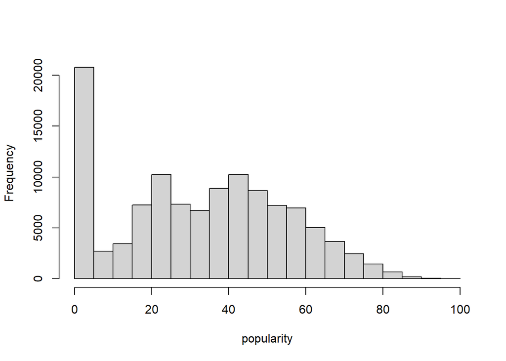

```
## Distribution of  duration_ms
```

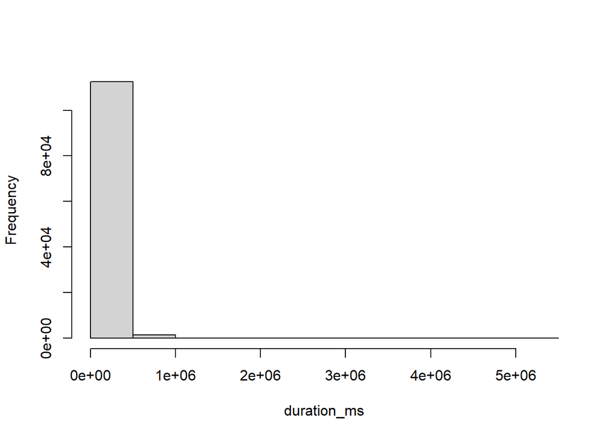

```
## Distribution of  danceability
```

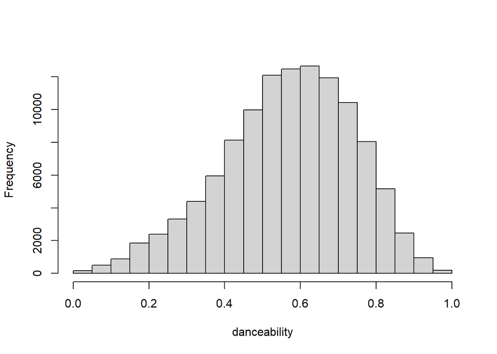

```
## Distribution of  energy
```

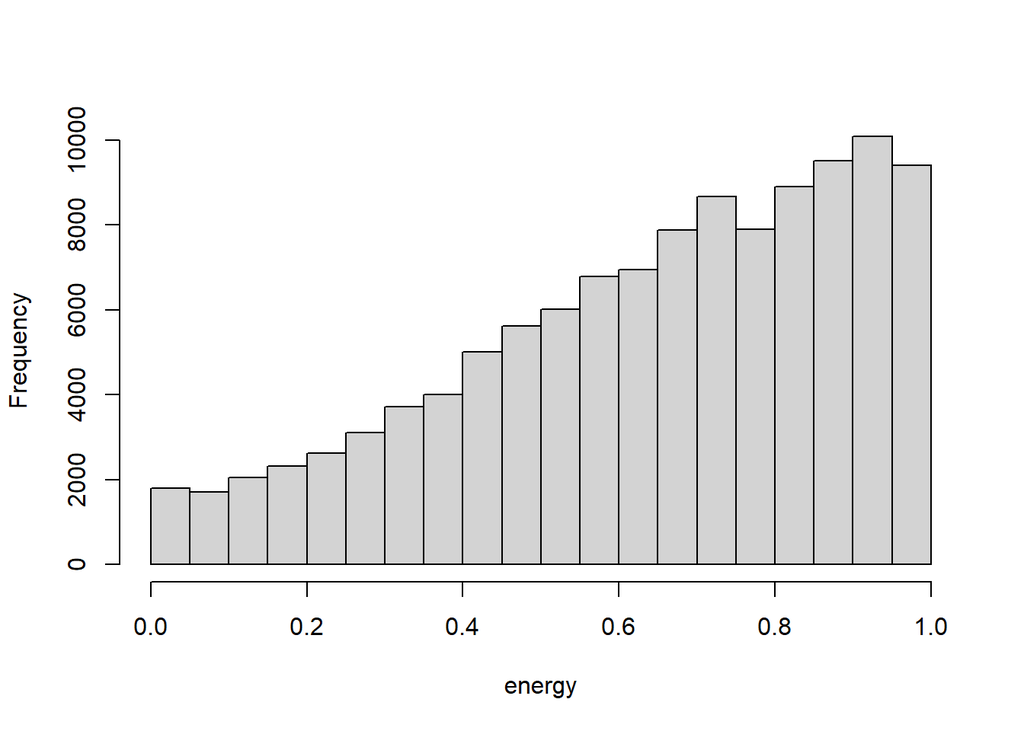

```
## Distribution of  acousticness
```

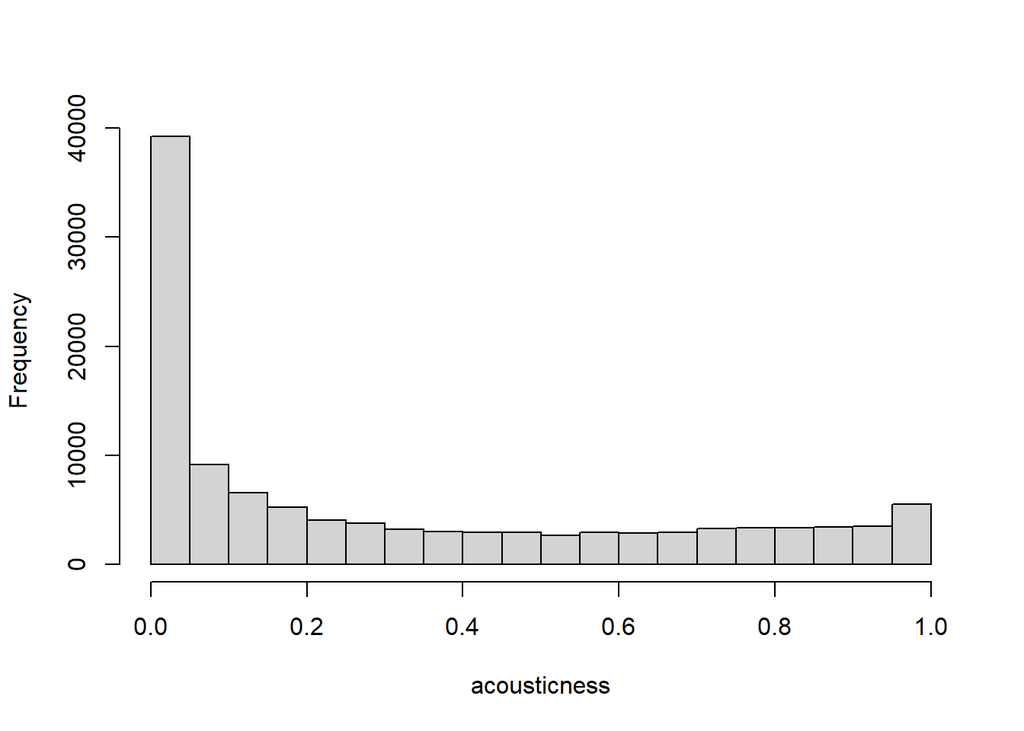

```
## Distribution of  instrumentalness
```

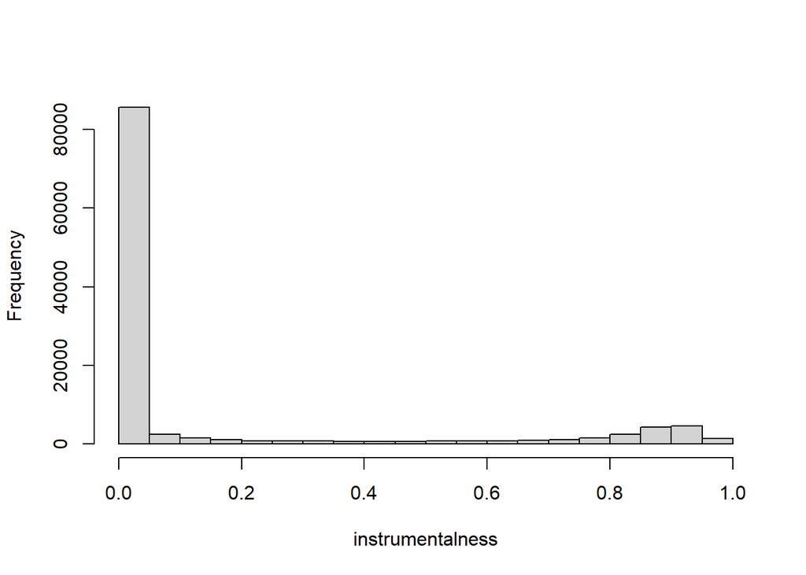

```
## Distribution of  liveness
```

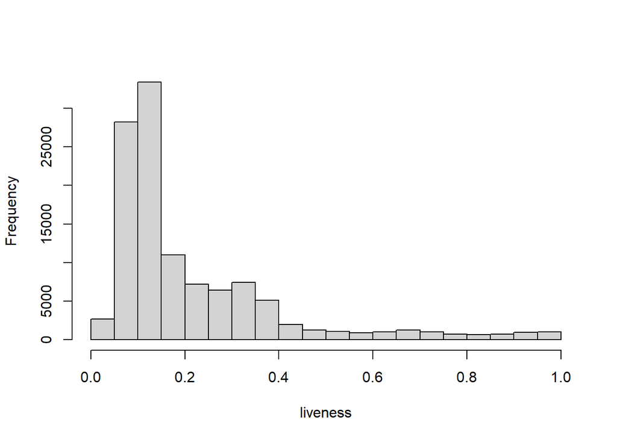

```
## Distribution of  tempo
```

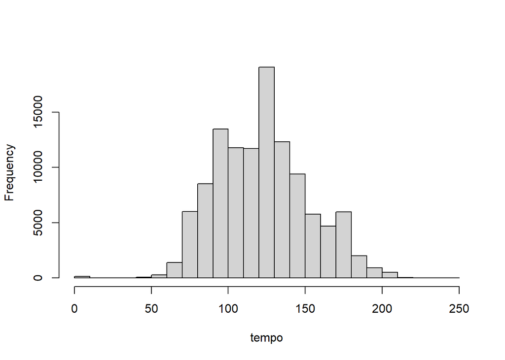

In general, this dataset looks fairly good and normalized, with features like `danceablity`, `energy`, `acousticness`, `instrumentalness`, `liveness` range between 0 and 1. `Popularity` seems to have been adjusted to the 0-100 scale. However, a potential issue stands out for `duration_ms` for some extreme outliers, as also pointed out in the histogram for `duration_ms`, (songs lasting over 5 million ms ≈ 87 minutes, which is unusual for typical songs).